# 23C R Project 2019

Michel Nehme, Ramiz A. Razzak

May 11, 2019

## Introduction

In the following markdown presentation, we will be providing a basic synopsis of the salient insights from our data analysis project. We hope you enjoy this brief presentation!

## Our focus

For our project, we analyzed data from Raj Chetty’s Equality of Opportunity project which goes over different metrics regarding a child’s economic situation based on their parent’s income percentile. The data is formatted in a specific way: it provides incomes for children based on the type of school they went to and their parent’s income percentile. There are 15 different educational categories, ranging from Ivy Plus to Never Attended college (before year 2013). Importantly, we focus on the interplay of level of educational attainment and future earning capacity across parental income percentiles.

## A starting point: average income accross educational categories

For starters, we wanted to look at the effect of different types of school levels on average income, irrespective of parental income percentile. We figured this would a good starting point and allow us to delve into deeper analysis which eventually incorporates parental income percentile.

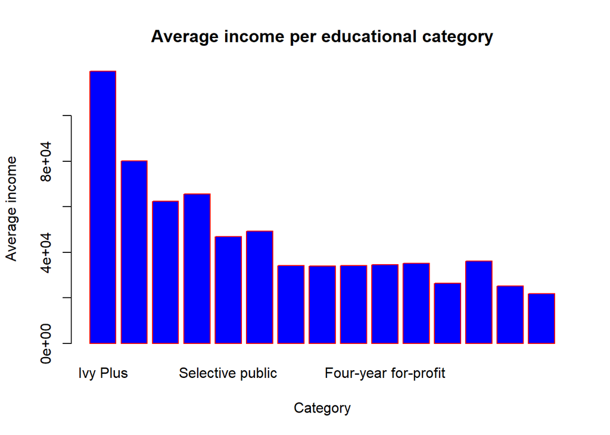

As we can see from this barplot, incomes seem to be decreasing as you go further down the level of college education accross all parental income percentiles. This observation is what motivated our decision to delve deeper into the effect of one’s educational category on their income. Nevertheless, it is salient to acknowledge that the most pronounced disparities occur near the top end of the university tiers; the difference between an ivy-league education (just under 120,000 dollars) and a highly-selective public college education (62,500 dollars) is much more significant than that between non-selective four-year private non-for-profit colleges and two-year for-proit colleges, for example, as starkly indicated by our bar plot. This perhaps indicates that at a certain point, level of tertiary education bears less upon future earning expectations - that is, education is not a requisite for a certain level of income.

## Delving deeper into the effect of educational category on child incomes

In this section, we conducted two types of independence tests, and compared the results: the first was a permutation test, and the second a chi-squared test. For our permutation test, we scrambled outcomes of ivy-league/elite incomes and highly-selective public/private incomes, then observed the difference between observed and expected values upon proceeding with this process of random sampling.

By contrast, for our chi-squared test, we configured a contingency table of ivy/elite incomes compared with highly selective public/private incomes, from which we used an R-function to compute a chi-statistic.

In both cases, we ended up with a very low p-value; in this regard, both approaches concorded in their conclusions.

One of the key insights of our analysis was that ivy-league and elite college incomes were significantly higher than incomes from all other categories, as indicated by our direct comparison with incomes of students from highly selective private and public colleges. This conclusion is actually quite salient, because if we make the relatively safe assumption that the quality of education between America’s top public and private colleges versus those that are Ivy/Ivy + (Elite) is almost functionally the same, we might be able to extrapolate that the large differential in income between students from Ivy+ Schools and top public and private colleges is primarily motivated by the signaling - that is to say, the esteem in which certain colleges are held due to historical reputation, institutional favour, etc.. There is a significant amount of economic literature which broaches this issue; for instance, economist Bryan Caplan believes that the value of education in America today is vastly exaggerated, since much of the increases in wages witnessed by those with college degrees depend on the college they’ve attended as opposed to the raw human capital they’ve gained. In our project, we performed a permutation test to arrive at this conclusion (by invalidating our null hypothesis that there wouldn’t be an income gap between Ivy + vs top public/private) and we supplemented this analysis by a classic chi-square test, receiving similarly low p-values in both circumstances and thus contravening our underlying hypothesis that there ought not functionally be a significant difference between the earning capacities of the two groups at this high level of college education.

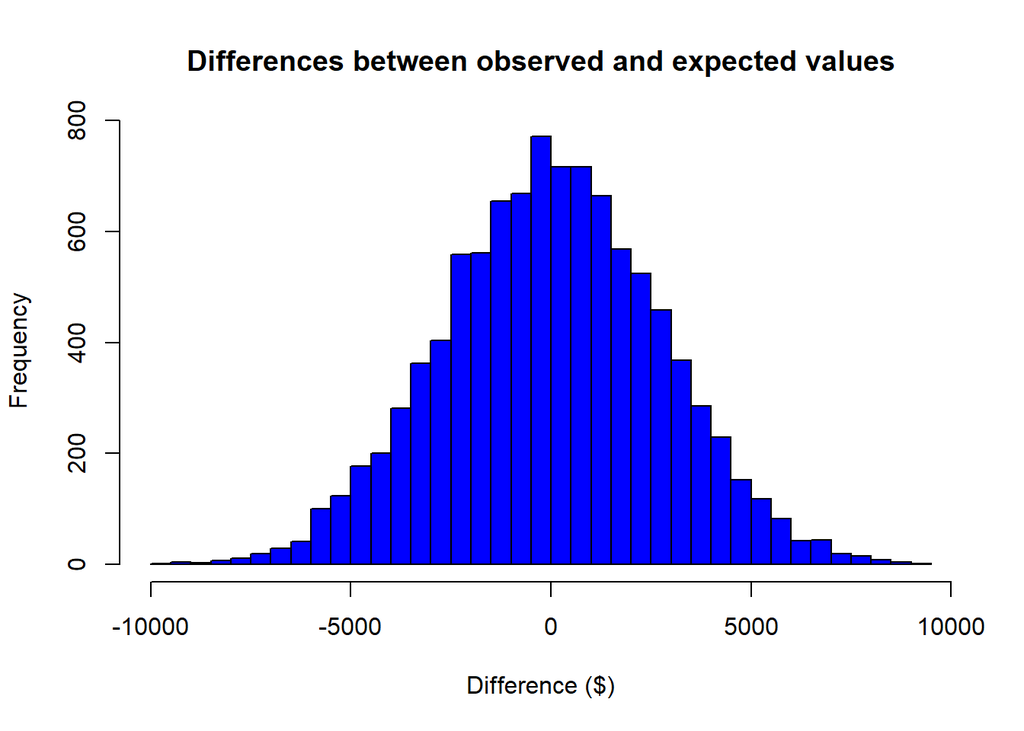

We furthered our statistical analysis by interogating the difference in incomes between students attending a four-year public with two-year for-profit colleges (across parental percentiles). We observe through a p-test that there is not a statistically significant discrepancy between their earnings, which is rather surprising prima facie. This seems to go against the idea that more years of education would lead to higher human capital accumulation which in turn would lead to higher income, and also contravenes much empirical academic analysis which compares mid-tier public and private schools and finds that private schools charge extortionately for essentially the same - if not worse - education. Our hypothesis for why this is the case again returns to signaling: similarly to how Ivy + students earn more money than their counterparts at equally challenging schools, because four-year public colleges and two-year for-profits convey a similar signal (they aren’t particularly prestigious, but highlight that the student has done beyond a high school degree) they lead to similar earnings. The difference between degree types becomes more marginal at the lower level, so the signal is restricted to the achievement of teritary education, and little more in terms of income. If this hypothesis is correct, it strengthens the conclusions we’ve made in the paragraph above.

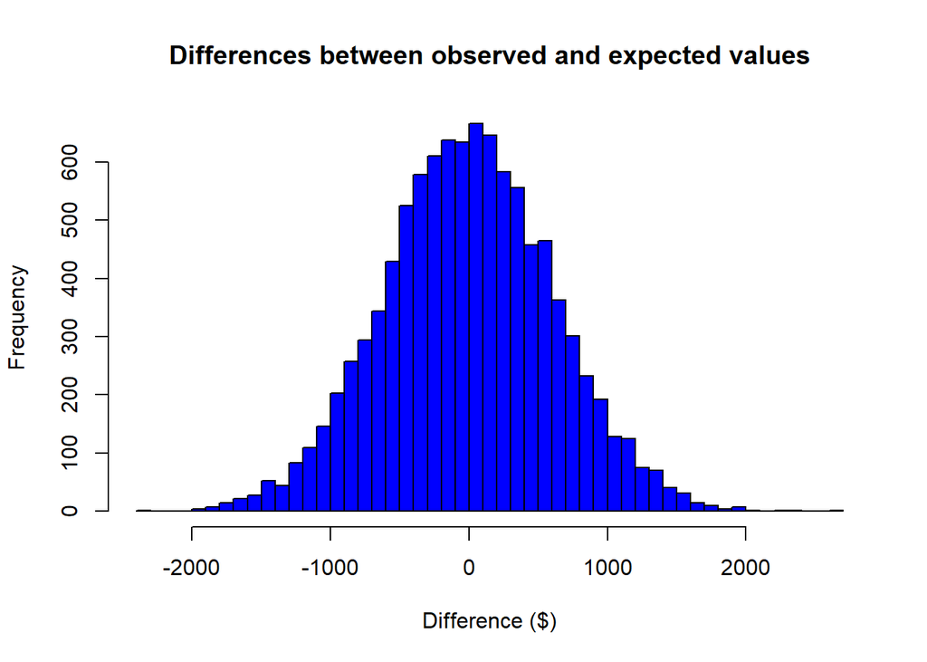

## Second key analytical insight: relating parental income to child income

Our second focus in this project is to see the effects of a parent’s standing in the economic ladder on their child’s income.

The following graph, with its corresponding linear regression line, plots this relationship.

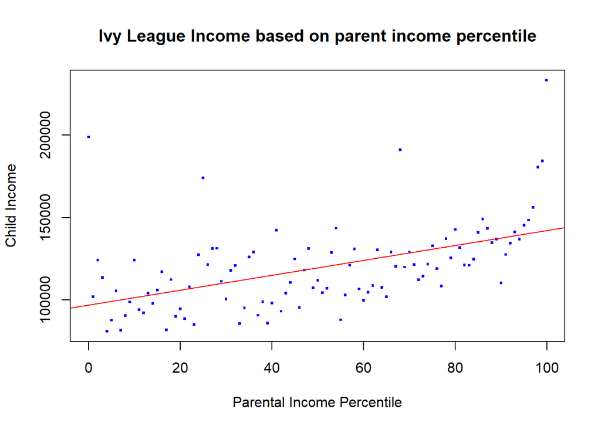

The key take away here is that there is a non-negligible correlation between parental income percentile and child earnings at the ivy-league level, albeit a less-pronounced one that you might have expected. By producing a linear correlation between these two variables and computing the strength of the correlation, we found a line of best fit and we computed the strength of the correlation, which turned out to be a little above 0.5. In most statistics textbooks, this is categorized as a moderate correlation. The take away here is with regards to economic mobility: the influence of parental income percentile on child income is present, but not extremely strong when they have attained an ivy-league education. This again is an important question in both economic literature and in politics, and our analysis seems to indicate that both those who believe that success is entirely related to personal effort and those who believe that the wealthy inevitably end up with wealthy children are overstating their case. Importantly, this emphasises that hereditary wealth becomes less of a factor in future earnings at the point at which you attain such an esteemed level of education, and suggests that Ivy-League degrees are therefore perhaps a conduit of comparative economic equality across people who manage to access them. There is, of course, the question of who is able to access them in the first place, but that exceeds the scope of our project.